# **Lista 1**

Nome: **Vitor Augusto Henrique Brisola** NºUSP: **9791292**

## Bibliotecas

```python
import networkx as nx
```

```python
import matplotlib.pyplot as plt
from numpy  import *
import numpy as np
```

```python
# setting working directory
#import os
#os.chdir(r"D:\Users\9791292\Desktop\projeto\data")
```

```python
from numpy.linalg import matrix_power
```

```python
import random as rand
```

## **Rotinas Essenciais**

*Sequência de funções que serão usadas em vários exercícios*

### Net Print

*Desenha rede na tela*

```python
# printing network
def print_net(N,with_labels=False,node_size=50,font_size= 16,label=None):
    if with_labels:
        labels = N.nodes()
    pos=nx.spring_layout(N)
    nx.draw(N, with_labels =  with_labels, node_size=node_size, font_size=font_size,pos=pos,label=label)
    plt.show(True)
```

### Get Net

*Importa rede em armazenamento local de acordo com o nome de arquivo*

```python
# net importing
def get_net(file_name, show = False):
    # reading
    G = nx.read_edgelist(file_name, nodetype=str, data=(('weight',float),))
    # drawing network
    if show:
        printnet(G)
    return G
```

### **Exercise Network**

*Construindo rede apresentada no exercício 1 e 4*

```python
def get_G_ex():
    G = nx.Graph()
    G.add_edge('1','2') # 1
    G.add_edge('1','4')
    G.add_edge('2','3') # 2
    G.add_edge('2','4')
    G.add_edge('3','4')
    G.add_edge('3','5') # 3
    G.add_edge('3','6')
    G.add_edge('3','7')
    G.add_edge('6','7') # 6
    return G
```

### Degree

```python
def get_degrees(G):
    vk = dict(G.degree())
    vk = list(vk.values())
    degree = np.array(vk)
    return degree
```

#### **Degree Distribution**

```python
# calc the degree distribution
def get_degree_distribution(G):
    vk = get_degrees(G)
    maxk = np.max(vk)
    mink = np.min(vk)
    kvalues= arange(0,maxk+1) # possible values of k
    Pk = np.zeros(maxk+1) # P(k)
    for k in vk:
        Pk[k] = Pk[k] + 1
    Pk = Pk/sum(Pk) # the sum of the elements of P(k) must to be equal to one
    return kvalues,Pk
```

```python
# plot degree distribution
def plot_degree_distribution(Ks, Pk,plot_type=None):
    fig = plt.subplot(1,1,1)
    #fig.set_xscale('log')
    #fig.set_yscale('log')

    # selecionando o tipo de plot('histogram','scatterplot',..)
    if plot_type == 'bo':
        plt.plot(Ks,Pk,'bo')
    #elif plot_type == 'hist':
    #    plt.hist(Ks,Pk, bins  = len(ks))
    else:
        plt.plot(Ks,Pk)

    plt.xlabel("k", fontsize=20)
    plt.ylabel("P(k)", fontsize=20)
    plt.title("Degree distribution", fontsize=20)
    #plt.grid(True)
    #plt.savefig('degree_dist.eps') #save the figure into a file
    plt.show(True)
```

```python
def momment_of_degree_distribution(G,m):
    k,Pk = get_degree_distribution(G)
    M = sum((k**m)*Pk)
    return M
```

```python
def momment_of_degree_distribution2(G,m):
    M = 0
    N = len(G)
    for i in G.nodes:
        M = M + G.degree(i)**m
    M = M/N
    return M
```

```python
def shannon_entropy(G):
    k,Pk = get_degree_distribution(G)
    H = 0
    for p in Pk:
        if(p > 0):
            H = H - p*math.log(p, 2)
    return H
```

```python
def normalized_shannon_entropy(G):
    k,Pk = get_degree_distribution(G)
    H = 0
    for p in Pk:
        if(p > 0):
            H = H - p*math.log(p, 2)
    return H/math.log(len(G),2)
```

### Probability Matrix

*Rotina para calcular a matrix de probabilidade de uma data rede.*

```python
def probability_matrix(G):
    adj_M = nx.to_numpy_matrix(G) # adjacency matrix
    degrees = get_degrees(G)

    for node_idx in range(len(degrees)):
        node = adj_M[node_idx]
        new_node = np.divide(node,degrees[node_idx])
        adj_M[node_idx] = new_node

    prob_M = adj_M
    return prob_M
```

### Distance

```python
def distance_matrix(G):
    N = len(G.nodes)
    D = zeros(shape=(N,N)) # D is the matrix of distances
    vl = []
    for i in arange(0,N):
        for j in arange(i+1, N):
            if(i != j):
                aux = nx.shortest_path(G,str(i+1),str(j+1))
                dij = len(aux)-1
                D[i][j] = dij
                D[j][i] = dij
                vl.append(dij)
    #x = range(0,d+1)

    return D
```

#### **Distribution of the shortest paths**

```python
def shortest_paths_distribution(G):
    if nx.is_connected(G) == True:
        N = len(G.nodes)
        D = zeros(shape=(N,N)) # D is the matrix of distances
        vl = []
        # getting distance
        for i in arange(0,N):
            for j in arange(i+1, N):
                if(i != j):
                    aux = nx.shortest_path(G,i,j)
                    dij = len(aux)-1
                    D[i][j] = dij
                    D[j][i] = dij
                    vl.append(dij)

        return vl
    else:
        print("The graph has more than one connected component")
```

```python
def draw_shortest_paths_distribution(G,vl=None):
    if not vl:
        vl = shortest_paths_distribution(G)
    d = nx.diameter(G)
    x = range(0,d+1)
    short = plt.hist(vl, bins = x)
    return short
```

### Random Walk

*A rotina abaixo simula uma caminhada aleatória pela rede e retorna uma lista com o número de vizitas recebidos por cada nó.*

```python
def random_walk(G,l):
    nv = np.zeros(len(G.nodes)+1) # visits counter for each node
    for node in G.nodes:
        exit = False
        num_steps = l
        pos = node
        while(not exit and num_steps > 0):
            neighbors = list(G.neighbors(pos))
            if(len(neighbors) > 0):
                next_node = neighbors[rand.randint(0,len(neighbors)-1)]
                nv[next_node] += 1 # visit counting
                pos = next_node
                num_steps -= 1
            else:
                exit = True

    return nv
```

### Components

**Largest Component** extracting

```python
def get_largest_component(G,show = False):
    Gcc=sorted(nx.connected_component_subgraphs(G), key = len, reverse=True)
    G=Gcc[0]
    # drawing largest component
    if show:
        print_net(G)
    return G
```

### Sampling

```python
def get_sample(G,k):
    sampled_nodes = rand.sample(G.nodes, k)
    G_sample = G.subgraph(sampled_nodes)
    G_sample_lc = get_largest_component(G_sample)

    return G_sample_lc
```

## Grafos Essenciais

*Importing de grafos que serão usados na resolução de vários exercícios*

```python
G_ex = get_G_ex()
```

```python
G_euro = get_net('data/euroroad.txt')
```

```python
G_lm = nx.read_edgelist('data/lesmis.txt', nodetype=str, data=(('weight',float),),create_using= nx.DiGraph())
```

```python
G_face = get_net('data/facebook_combined.txt')
```

```python
G_scie = nx.read_gml('data/netscience.gml')
```

```python
G_hams = get_net('data/petster-friendships-hamster-uniq.txt')
```

```python
G_astro = get_net('data/ca-AstroPh.txt')
```

## **Exercício 1**

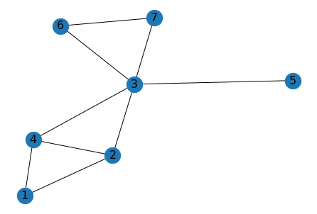

```python
# plotando rede apresentada na descrição do exercício
print_net(G_ex,with_labels=True)
```

### PART A

```python
# carregando a distribuição de grau do grafo
ks_ex, Pk_ex = get_degree_distribution(G_ex)
```

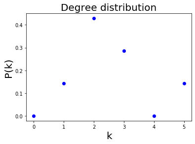

```python
plot_degree_distribution(ks_ex,Pk_ex,'bo')
```

### PART B

```python
# local clustering coefficient
avc = nx.average_clustering(G_ex)
print("Local clustering coefficent:", "%3.4f"%avc)
```

[output not shown]

### PART C

```python
# transitivity
CC = (nx.transitivity(G_ex))
print("Transitivity: ","%3.4f"%CC)
```

```
Transitivity:  0.4737
```

### PART D

```python
D_ex = distance_matrix(G_ex)
print(D_ex)
```

```
[[0. 1. 2. 1. 3. 3. 3.]
 [1. 0. 1. 1. 2. 2. 2.]
 [2. 1. 0. 1. 1. 1. 1.]
 [1. 1. 1. 0. 2. 2. 2.]
 [3. 2. 1. 2. 0. 2. 2.]
 [3. 2. 1. 2. 2. 0. 1.]
 [3. 2. 1. 2. 2. 1. 0.]]
```

### PART E

```python
H = shannon_entropy(G_ex)
print("Shannon Entropy = ", "%3.4f"%H)
H = normalized_shannon_entropy(G_ex)
print("Normalized Shannon Entropy = ", "%3.4f"%H)
```

```
Shannon Entropy =  1.8424
Normalized Shannon Entropy =  0.6563
```

### PART F

```python
momment_of_degree_distribution(G_ex,2)
```

```
7.999999999999999
```

## **Exercício 2**

#### Desenhando Rede *Les Miserables* direcionada e com pesos

*Cada aresta possui uma espessura, a qual representa o peso da aresta*

```python
# extraindo pesos
edges = G_lm.edges()
weights = [G_lm[u][v]['weight'] for u,v in edges]
```

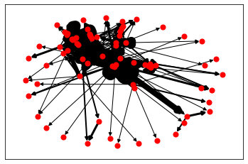

```python
# desenhando grafo com pesos
pos=nx.spring_layout(G_lm)
nx.draw_networkx(G_lm, with_labels = False, node_color='red', edge_color='black',
        node_size=50, font_size=16, pos=pos, width=weights, label='Les Miserables weighted graph')
plt.show(True)
```

#### Desenhando Rede *Les Miserables* não direcionada e sem pesos

```python
# transforming network to undirected
G_undir_lm = G_lm.to_undirected()
```

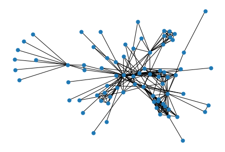

```python
print_net(G_undir_lm,node_size=50,label='Les Miserables undirected')
```

**Conclusão:** A rede sem pesos e não direcionada é muito mais fácil de ser vizualida e tambem melhor de ser processada. Porém, a analize da rede sem pesos e não direcionada não será uma completa e pode ter informações cruciais faltando.

## **Exercício 3**

**Les Miserables network** será usada no exercício

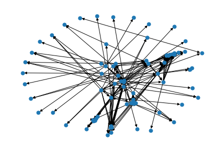

```python
# vizualizando rede
print_net(G_lm, node_size=50,label='Les Miserables Network')
```

```python
# realizando random walk
visits_lm = random_walk(G_lm,10)
print(visits_lm)
```

```
[ 0.  0.  1.  0.  1.  0.  0.  0.  2.  0.  0.  2.  0.  0.  0.  0.  0.  0.
  1.  0.  1.  1.  1.  5.  7.  2.  2.  1.  0.  0.  2.  1.  4.  0.  0.  1.
  1.  2.  3.  7.  0.  0.  0.  2.  0.  1.  0.  0.  0.  2.  0.  0.  0.  0.
  1.  1.  6.  3.  2.  1.  2.  0.  1.  3.  5.  5.  6.  7.  0.  1.  3.  6.
  2.  0.  0.  1. 12. 15.]
```

```python
# grau de cada nó
vk_lm = dict(G_lm.degree())
vk_lm = list(vk_lm.values())
degree_lm = np.array(vk)
print('Degree', degree_lm)
```

```
Degree [ 1 10  3  3  1  1  1  1  1  1 36  1  2  1  1  1 15 11 16 11 17  4  8  4
  1  2  6  6  6  6  6  3  2 22  7  7 19 15 13 10 10 10  9  3  7  9  7  7
  7  7  7  2 11  3  2  3  1  7  4  1  2 11 13  2  1 11  9 11 12 12 10  2
  2  7  2  1  1]
```

**Correlação entre número de visitas e grau do nó**

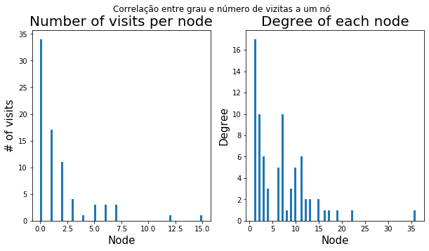

```python
# ploting visits
fig, ax = plt.subplots(1, 2,figsize=(10,5))
fig.suptitle('Correlação entre grau e número de vizitas a um nó')

# Nro de Visitas
ax[0].hist(visits_lm, bins  = len(visits_lm))
ax[0].set_title("Number of visits per node", fontsize=20)
ax[0].set_ylabel("# of visits", fontsize=15)
ax[0].set_xlabel("Node", fontsize=15)

# Grau de cada nó
ax[1].hist(degree_lm, bins  = len(degree_lm))
ax[1].set_title("Degree of each node", fontsize=20)
ax[1].set_ylabel("Degree", fontsize=15)
ax[1].set_xlabel("Node", fontsize=15)

#plt.grid(True)
#plt.savefig('visits.eps') #save the figure into a file
plt.show()
```

## **Exercício 4**

**Rede usada no exercício**

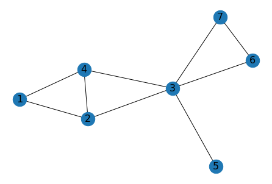

```python
print_net(G_ex,with_labels=True)
```

### PART A

```python
# carregando matrizes de probabilidade
powers = [10,100,1000]
pm = dict()
pm['1'] = probability_matrix(G_ex)
for power in powers:
    pm[power] = matrix_power(pm['1'],power)
    # vizualizando matrizes resultantes
    #print("=== Probability Matrix Powered by "+str(power)+" ===")
    #print(pm[power])
    #print('\n')
```

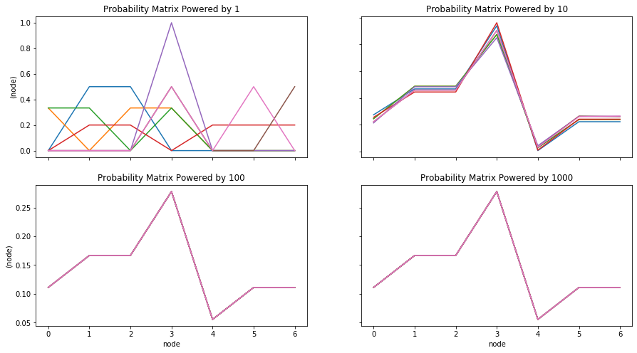

```python
# ploting transpose matrix
fig, axs = plt.subplots(2, 2,figsize=(15,8))

for ax,key in zip(axs.flat,pm):
    ax.plot(pm[key].transpose())
    ax.set_title('Probability Matrix Powered by '+str(key))
    ax.set(xlabel='node', ylabel='(node)')

# Hide x labels and tick labels for top plots and y ticks for right plots.
for ax in axs.flat:
    ax.label_outer()
```

> **Transpose Matrix Ploting:** A matriz transposta da matriz de probabilidade coloca a probabilidade deum nó ser percorrido iniciado-se em um determinado nó, dado agora pela coluna. Logo a figura acima mostra como a probabilidade de um nó ser percorrido torna-se independente do nó inicial .

#### Comparando matrix de probabilidade de grau 100 com o grau de cada nó

```python
# Carregando grau
degree_ex = get_degrees(G_ex)
```

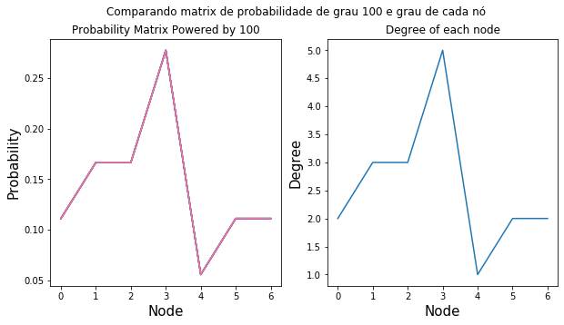

```python
fig, (ax1, ax2) = plt.subplots(1, 2,figsize=(10,5))
fig.suptitle('Comparando matrix de probabilidade de grau 100 e grau de cada nó')
# probability matrix powered by 100
l=100
ax1.plot(pm[l].transpose())
ax1.set_title('Probability Matrix Powered by '+str(l))
ax1.set_ylabel("Probability", fontsize=15)
ax1.set_xlabel("Node", fontsize=15)
# degrees
ax2.plot(degree_ex)
ax2.set_title("Degree of each node")
ax2.set_ylabel("Degree", fontsize=15)
ax2.set_xlabel("Node", fontsize=15)
```

> **Correlação com o grau**: Podemos observar uma grande correlação entre o grau de um nó e a probabilidade de o mesmo ser acessado durante uma caminhada aleatória de grau alto (100 no exemplo).

**CONCLUSÃO:** Como podemos observar com os dados apresentados anteriormente conforme **n** aumenta a matriz tende a apresentar valores iguais de probabilidade de chegada para cada nó. Isso ocorre pois o processo pode ser interpretado como uma caminhada aleatória de passos **n** e quanto maior o número de passos mais a probabilidade de chegada a um determinado depende menos do nó inicial e mais do grau do nó.

### PART B

#### Rede usada no exercício

[figure not shown]

```python
# Les Miserables
G_undir_lm = G_lm.to_undirected()
net_print(G_undir_lm)
```

#### Calculando A e A³

```python
A = nx.to_numpy_matrix(G_undir_lm)
#print(A)
```

```python
A_3 = matrix_power(A,3)
#print(A_3)
```

#### Calculando Distancia

```python
D = distance_matrix(G_undir_lm)
#print(D)
```

#### Comparando distribuição de A³ e de Distância

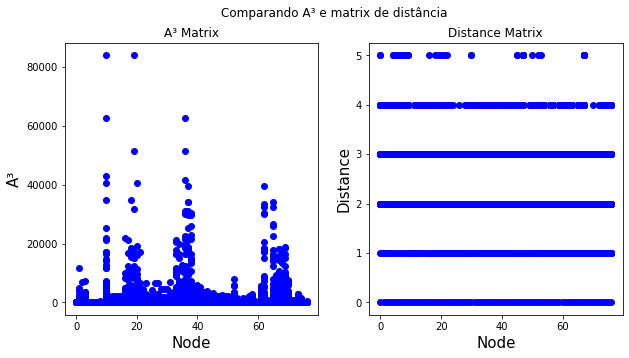

```python
fig, ax = plt.subplots(1, 2,figsize=(10,5))
fig.suptitle('Comparando A³ e matrix de distância')

# A³ matrix
ax[0].plot(A_3,'bo')
ax[0].set_title('A³ Matrix')
ax[0].set_ylabel("A³", fontsize=15)
ax[0].set_xlabel("Node", fontsize=15)

# distancia
ax[1].plot(D,'bo')
ax[1].set_title("Distance Matrix")
ax[1].set_ylabel("Distance", fontsize=15)
ax[1].set_xlabel("Node", fontsize=15)
```

[figure not shown]

```python
plt.figure()b
plt.plot(D,A_3,'bo')
plt.title('A³ by Distance Matrix')
plt.ylabel("A³", fontsize=15)
plt.xlabel("Distance", fontsize=15)
```

## **Exercício 6**

### **PART A:** *E-road network*

```python
# rede a ser usada
len(G_euro.nodes)
#print_net(G_euro)
```

```
1174
```

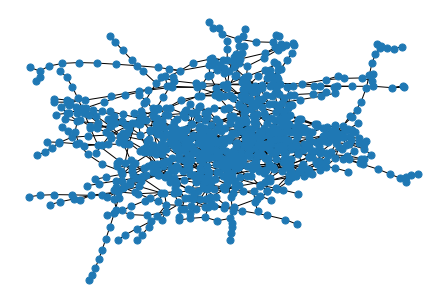

```
1039
```

```python
# extraindo maior componente
G_euro_lc = get_largest_component(G_euro,show= True)
len(G_euro_lc.nodes)
```

```python
ks_euro,Pk_euro = get_degree_distribution(G_euro_lc)
```

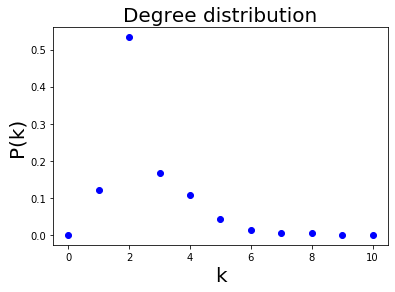

```python
plot_degree_distribution(ks_euro,Pk_euro,'bo')
```

**Conclusão:** A rede de conexões de rodovias europeias apresenta uma distribuição que é mais caracteristica de uma rede 'Small World'. Isso pode ser interpretado pelo fato de a conexão entre cidades por rodovia é altamente dependente da localização, portanto não é tão dependente do fato de a cidade ser grande ou pequena, mas sim de quantas cidades estão próximas a ela. Isso poderia ser diferente se ao invés de analizar as rodovias que conectam as cidade vissemos analizassemos o destino de transporte rodoviário. Neste caso, muitas cidades estariam conectadas a metropoles mesmo estando distantes.

### **PART B**

```python
len(G_face.nodes)
#print_net(G_face)
```

```
4039
```

```python
G_face_lc = get_largest_component(G_face)
len(G_face_lc.nodes)
```

```
4039
```

```python
Ks_face_lc,Pk_face_lc = get_degree_distribution(G_face_lc)
```

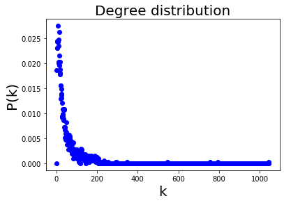

```python
plot_degree_distribution(Ks_face_lc,Pk_face_lc,'bo')
```

**Conclusão:** Com esperado de uma rede social real, a rede amizades do facebook apresenta uma distribuição muito caracteristica de uma rede 'Scale-free'. Como pode ser interpretado muitos usuários possuem conexão com poucos amigos(menos de 200) enquanto uma pequena minoria apresenta muitas conexões (>200).

### **PART C**

```python
len(G_scie.nodes)
#print_net(G_scie)
```

```
1589
```

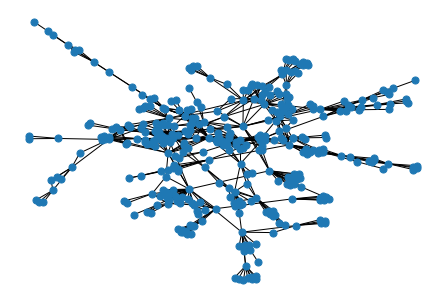

```
379
```

```python
G_scie_lc = get_largest_component(G_scie,show= True)
len(G_scie_lc.nodes)
```

```python
Ks_scie_lc,Pk_scie_lc = get_degree_distribution(G_scie_lc)
```

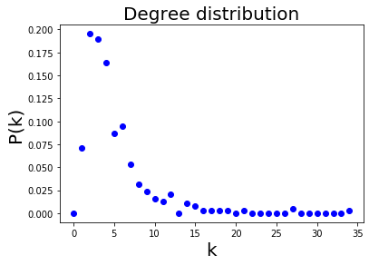

```python
plot_degree_distribution(Ks_scie_lc,Pk_scie_lc,'bo')
```

**Conclusão:** A rede de co-autoria de pesquisadores trabalhando com teoria de redes e experimentos aprenseta, como esperado, um distribuição caracteristica de uma rede 'Small World' com um número maior de co-autoria entre poucos autores. Esse comportamento poderia ser esperado, pois muitos artigos apresentam um número pequeno de pesquisadores e um maior número irá apresentar autoria entre varios autores (35 autores por exemplo).

### **PART D**

```python
len(G_hams.nodes)
#print_net(G_hams)
```

```
1858
```

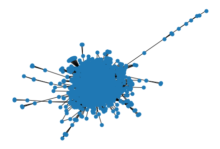

```
1788
```

```python
G_hams_lc = get_largest_component(G_hams,show= True)
len(G_hams_lc.nodes)
```

```python
Ks_hams_lc,Pk_hams_lc = get_degree_distribution(G_hams_lc)
```

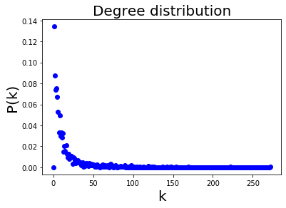

```python
plot_degree_distribution(Ks_hams_lc,Pk_hams_lc,'bo')
```

**Conclusão:** A rede social de conexão entre usuarios do site hamsterster.com apresenta, como esperado de uma rede social, um corportamento de distribuição caracteristico de uma rede 'Scalle-free'. A grande maioria de usuarios se conectam com um número pequeno de usuários (<50) enquanto um número bem baixo possue conexão com muitos usuários(>200).

## **Exercise 7**

**Clustering Coeficient & Transitivity**

### **PART A**: Euro roads network

```python
# transitivity
CC = (nx.transitivity(G_euro))
print("Transitivity: ","%3.4f"%CC)
# avarage clustering
avc = nx.average_clustering(G_euro)
print("Average clustering:", "%3.4f"%avc)
```

```
Transitivity:  0.0339
Average clustering: 0.0167
```

### **PART B**: Facebook user-user friendship network

```python
# transitivity
CC = (nx.transitivity(G_face))
print("Transitivity: ","%3.4f"%CC)
# avarage clustering
avc = nx.average_clustering(G_face)
print("Average clustering:", "%3.4f"%avc)
```

```
Transitivity:  0.5192
Average clustering: 0.6055
```

### **PART C**: Collaboration of authors of scientific papers from the arXiv’s Astrophysics

```python
print(len(G_astro.nodes))
```

```
18771
```

```python
# transitivity
CC = (nx.transitivity(G_astro))
print("Transitivity: ","%3.4f"%CC)
# avarage clustering
avc = nx.average_clustering(G_astro)
print("Average clustering:", "%3.4f"%avc)
```

```
Transitivity:  0.3180
Average clustering: 0.6306
```

### **PART D**: Hamsterster friendships network

```python
# transitivity
CC = (nx.transitivity(G_hams))
print("Transitivity: ","%3.4f"%CC)
# avarage clustering
avc = nx.average_clustering(G_hams)
print("Average clustering:", "%3.4f"%avc)
```

```
Transitivity:  0.0904
Average clustering: 0.1414
```

### Why do C and CL diverge in some networks?

**Conclusão:** Transitividade e *Clustering Coefficient* tentam medir a mesma coisa, o número de triangulos de uma rede, porém fazem isso por processos diferentes e pportanto são medidas diferentes. Alguns fatores podem causar a divergência entre essas medidas, um exemplo seria uma rede em que nós de baixo grau sõa pouco conectados com nós de alto grau.

## **Exercise 8**

### **PART A**: Euro roads network

```python
G_euro_lc = get_largest_component(G_euro)
len(G_euro_lc.nodes)
```

```
1039
```

```python
G_euro_lc = nx.convert_node_labels_to_integers(G_euro_lc, first_label=0)
```

```python
vl_euro = shortest_paths_distribution(G_euro_lc)
```

### **PART B**: Facebook user-user friendship network

```python
G_face_lc = get_largest_component(G_face)
len(G_face_lc.nodes)
```

```
4039
```

```python
G_face_lc = nx.convert_node_labels_to_integers(G_face_lc, first_label=0)
```

```python
G_face_sample = get_sample(G_face_lc,2000)
len(G_face_sample)
```

```python
G_face_sample = nx.convert_node_labels_to_integers(G_face_sample, first_label=0)
```

```python
vl_face = shortest_paths_distribution(G_face_sample)
```

### **PART C**: Collaboration of authors of scientific papers from the arXiv’s Astrophysics

```python
# getting largest component
G_astro_lc = get_largest_component(G_astro)
len(G_astro_lc.nodes)
```

```
17903
```

```python
G_astro_lc = nx.convert_node_labels_to_integers(G_astro_lc, first_label=0)
```

```python
G_astro_sample = get_sample(G_astro_lc,2000)
len(G_astro_sample)
```

```
936
```

```python
G_astro_sample = nx.convert_node_labels_to_integers(G_astro_sample, first_label=0)
```

```python
vl_astro = shortest_paths_distribution(G_astro_sample)
```

### **PART D**: Hamsterster friendships network

```python
# getting largest component
G_hams_lc = get_largest_component(G_hams)
len(G_hams_lc.nodes)
```

```
1788
```

```python
G_hams_lc = nx.convert_node_labels_to_integers(G_hams_lc, first_label=0)
```

```python
vl_hams = shortest_paths_distribution(G_hams_lc)
```

### Comparando Distribuições

[figure not shown]

```python
fig,ax = plt.subplots(2, 2,figsize=(15,8))
fig.suptitle('Shortest Paths Distribution', fontsize=20)

d = nx.diameter(G_euro_lc)
x = range(0,d+1)
ax[0,0].hist(vl_euro, bins = x)
ax[0,0].set_ylabel("P(l)", fontsize=20)
ax[0,0].set_title("E-Road", fontsize=14)

d = nx.diameter(G_face_sample)
x = range(0,d+1)
ax[0,1].hist(vl_face, bins = x)
ax[0,1].set_title("Facebook friendship", fontsize=14)

d = nx.diameter(G_astro_sample)
x = range(0,d+1)
ax[1,0].hist(vl_astro, bins = x)
ax[1,0].set_ylabel("P(l)", fontsize=20)
ax[1,0].set_xlabel("l", fontsize=20)
ax[1,0].set_title("arXiv’s Astrophysics", fontsize=14)

d = nx.diameter(G_hams_lc)
x = range(0,d+1)
ax[1,1].hist(vl_hams, bins = x)
ax[1,1].set_xlabel("l", fontsize=20)
ax[1,1].set_title("Hamsterster friendships", fontsize=14)

plt.show()
```

**Conclusão:** Podemos observar que redes com natureza 'Scalle-free'(Facebook e Hamsterster) apresentam transições mais bruscas entre o número de nós com determinado tamanho de caminho mais curto quando comparado com as outras redes. Isso pode sr explicado pelo fato de que redes com natureza 'Scalle-free' terão comunidades de nós mais favorecidos quando ligado a nós "super-populares", ou seja, esse nós favorecem aconexão entre muitos nós pois eles só necessitam se comunicar passado pelo mesmo ou mais um. Assim, nós mais distantes desses nós super-populares terão uma comunicação dificultada com uma grande parte dos outros nós.

## **Exercise 9**

### **Table** construction

```python
def get_table(G):
    table = [['Number of nodes',len(G)],
            ['Average degree',np.mean(get_degrees(G))],
            ['second moment of degree distribution',momment_of_degree_distribution(G,2)],
            ['average clustering coefficient',nx.average_clustering(G)],
            ['transitivity',nx.transitivity(G)],
            [' average shortest path length',nx.average_shortest_path_length(G)],
            [' diameter',nx.diameter(G)]]
    return np.array(table)
```

```python
def table_draw(table_data,labels):
    table = plt.table(cellText=table_data,colLabels=labels,cellLoc='right',loc='best')
    table.set_fontsize(34)
    table.scale(1, 2)
    return table
```

```python
def table_plot(table_data,labels,title=None):
    plt.figure(figsize=(7,3))
    if title: plt.title(title, fontsize=20)
    plt.axis('tight')
    plt.axis('off')
    ytable = plt.table(cellText=table_data,colLabels=labels,cellLoc='right',loc='best')
    ytable.set_fontsize(34)
    ytable.scale(1, 2)
    plt.show()
```

**Column labels**

```python
labels = ['Measures','Values']
```

### **PART A**: Euro roads network

```python
G_euro_lc = get_largest_component(G_euro)
len(G_euro_lc.nodes)
```

```
1039
```

```python
G_euro_lc = nx.convert_node_labels_to_integers(G_euro_lc, first_label=0)
```

```python
table_euro = get_table(G_euro_lc)
#print(table_euro)
```

### **PART B**: Facebook user-user friendship network

```python
G_face_lc = get_largest_component(G_face)
len(G_face_lc.nodes)
```

```
4039
```

```python
G_face_lc = nx.convert_node_labels_to_integers(G_face_lc, first_label=0)
```

```python
table_face = get_table(G_face_sample)
#print(table_euro)
```

```python
G_face_sample = get_sample(G_face_lc,1000)
len(G_face_sample)
```

```
505
```

```python
G_face_sample = nx.convert_node_labels_to_integers(G_face_sample, first_label=0)
```

### **PART C**: Collaboration of authors of scientific papers from the arXiv’s Astrophysics

```python
# getting largest component
G_astro_lc = get_largest_component(G_astro)
len(G_astro_lc.nodes)
```

```
17903
```

```python
G_astro_lc = nx.convert_node_labels_to_integers(G_astro_lc, first_label=0)
```

```python
G_astro_sample = get_sample(G_astro_lc,2000)
len(G_astro_sample)
```

```
941
```

```python
G_astro_sample = nx.convert_node_labels_to_integers(G_astro_sample, first_label=0)
```

```python
table_astro = get_table(G_astro_sample)
#print(table_euro)
```

### **PART D**: Hamsterster friendships network

```python
# getting largest component
G_hams_lc = get_largest_component(G_hams)
len(G_hams_lc.nodes)
```

```
1788
```

```python
G_hams_lc = nx.convert_node_labels_to_integers(G_hams_lc, first_label=0)
```

```python
table_hams = get_table(G_hams_lc)
#print(table_euro)
```

### Comparando Medidas

[figure not shown]

```python
# plotando tabelas
fig,ax = plt.subplots(2,2,figsize=(15,12))

labels = ['Medidas','Valores']

# E-road
tb_euro = ax[0,0].table(cellText=table_euro,colLabels=labels,cellLoc='right',loc='best')
tb_euro.set_fontsize(14)
tb_euro.scale(1, 3)
ax[0,0].set_title("E-Road", fontsize=16)

# Facebook
tb_face = ax[0,1].table(cellText=table_face,colLabels=labels,cellLoc='right',loc='best')
tb_face.set_fontsize(14)
tb_face.scale(1, 3)
ax[0,1].set_title("Facebook Friendship", fontsize=16)

# Astro
tb_astro = ax[1,0].table(cellText=table_astro,colLabels=labels,cellLoc='right',loc='best')
tb_astro.set_fontsize(14)
tb_astro.scale(1, 3)
ax[1,0].set_title("arXiv’s Astrophysics", fontsize=16)

# Hamsterster
tb_hams = ax[1,1].table(cellText=table_hams,colLabels=labels,cellLoc='right',loc='best')
tb_hams.set_fontsize(14)
tb_hams.scale(1, 3)
ax[1,1].set_title("Hamsterster Friendship", fontsize=16)


ax[0,0].axis('tight')
ax[0,0].axis('off')
ax[0,1].axis('tight')
ax[0,1].axis('off')
ax[1,0].axis('tight')
ax[1,0].axis('off')
ax[1,1].axis('tight')
ax[1,1].axis('off')

plt.show()
```

**Conclusão:** Analisando as medidas presentes na table podemos observar alguns comportamentos:

- redes sociais como a do Facebook e do Hamsterster apresentam maior grau de conexão entre nós, podemos observar isso no grau médio dessas redes, os quais são bem maiores que o grau médio e segundo momento da distribuição de grau das outras duas.
- redes como Facebook e a de colaboração de autores (arXiv's Astrophysics) apresentam maior coeficiente de clusterização e transitividade. Isso pode ser explicado pelo fato de ambas as redes representam relações com maior vinculo entre nós próximos. Por exemplo, a colaboração de autores exige uma maior proximidade entre eles, o que tonar mais fácil a conexão com autores próximos.
- uma rede que representa ligações de rodovias com o a E-road irá apresentar maior média de caminhos (shortest path lenght) e maior diametro, isso porque o caminho entre cidades na grande maioria das vezes irá possuir outras cidades no meio, outra consequência da baixa clusterização dessa rede.

> **Número de Nós:** Para facilitar o processamento algumas redes foram diminuidas, por isso o número de nós menor.

## **Exercise 10**

### **Cities Networks** importing

#### New York

```python
G_ny = nx.read_graphml('data/New_York.graphml.xml')
G_ny = get_largest_component(G_ny.to_undirected())
G_ny = nx.convert_node_labels_to_integers(G_ny, first_label=0)
len(G_ny)
```

```
55206
```

```python
# extraindo amostra
G_ny_sample = get_sample(G_ny,35000)
G_ny_sample = nx.convert_node_labels_to_integers(G_ny_sample, first_label=0)
len(G_ny_sample)
```

```
1836
```

```python
# cleaning old
G_ny.clear()
```

#### Paris

```python
G_ps = nx.read_graphml('data/Paris.graphml.xml')
G_ps = get_largest_component(G_ps.to_undirected())
G_ps = nx.convert_node_labels_to_integers(G_ps, first_label=0)
len(G_ps)
```

```
10104
```

```python
# extraindo amostra
G_ps_sample = get_sample(G_ps,7000)
G_ps_sample = nx.convert_node_labels_to_integers(G_ps_sample, first_label=0)
len(G_ps_sample)
```

```
1845
```

```python
G_ps.clear()
```

#### Kansas City

```python
G_ks = nx.read_graphml('data/Kansas_City.graphml')
G_ks = get_largest_component(G_sp.to_undirected())
G_ks = nx.convert_node_labels_to_integers(G_ks, first_label=0)
len(G_ks)
```

[output not shown]

```python
# extraindo amostra
G_ks_sample = get_sample(G_ks,5500)
G_ks_sample = nx.convert_node_labels_to_integers(G_ks_sample, first_label=0)
len(G_ks_sample)
```

```
1334
```

```python
G_ks.clear()
```

### Degree Distribution

```python
# New York
Degree_Dist_ny = get_degree_distribution(G_ny_sample)
```

```python
# Paris
Degree_Dist_ps = get_degree_distribution(G_ps_sample)
```

```python
# Kansas City
Degree_Dist_ks = get_degree_distribution(G_ks_sample)
```

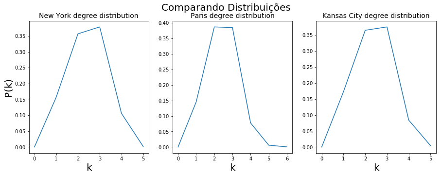

```python
# Distribtições lado a lado
fig,(ax1,ax2,ax3) = plt.subplots(1, 3,figsize=(15,5))
fig.suptitle('Comparando Distribuições', fontsize=20)

# New York
ax1.plot(Degree_Dist_ny[0],Degree_Dist_ny[1])
ax1.set_xlabel("k", fontsize=20)
ax1.set_ylabel("P(k)", fontsize=20)
ax1.set_title("New York degree distribution", fontsize=14)

#Paris
ax2.plot(Degree_Dist_ps[0],Degree_Dist_ps[1])
ax2.set_xlabel("k", fontsize=20)
ax2.set_title("Paris degree distribution", fontsize=14)

# Kansas City
ax3.plot(Degree_Dist_ks[0],Degree_Dist_ks[1])
ax3.set_xlabel("k", fontsize=20)
ax3.set_title("Kansas City degree distribution", fontsize=14)

plt.show()
```

> **Conclusão:** As distribuições de grau dessas cidade nos mostram que todas possuem uma rede características de 'Small World'. Logo, podemos inferir pelas amostras que o grau médio de conexão nas cidades é de 2 à 3. Isso é uma característica esperada de tal rede, visto que é difícil para um bloco possui acesso de vária ruas em um caso real de uma cidade.

### Complexity Measure

```python
# New York
complexity_ny = normalized_shannon_entropy(G_ny_sample)
```

```python
# Paris
complexity_ps = normalized_shannon_entropy(G_ps_sample)
```

```python
# Kansas city
complexity_ks = normalized_shannon_entropy(G_ks_sample)
```

### Average shortest path lenght

```python
# New York
short_ny = nx.average_shortest_path_length(G_ny_sample)
```

```python
# Paris
short_ps = nx.average_shortest_path_length(G_ps_sample)
```

```python
# Kansas City
short_ks = nx.average_shortest_path_length(G_ks_sample)
```

### Clustering Coefficient

```python
def weighted(M):
    # create weighted graph from M
    G = nx.Graph()
    for u,v in M.edges():
        if G.has_edge(u,v):
            G[u][v]['weight'] += 1
        else:
            G.add_edge(u, v, weight=1)
    return G
```

```python
# New York
clust_ny = nx.average_clustering(weighted(G_ny_sample))
```

```python
# Paris
clust_ps = nx.average_clustering(weighted(G_ps_sample))
```

```python
# Sao Paulo
clust_ks = nx.average_clustering(weighted(G_ks_sample))
```

### Comparação de Valores

```python
# Construindo tabelas
table_ny = [['Complexity Measure',complexity_ny],
            ['Average shortest path lenght',short_ny],
            ['Clustering Coefficient',clust_ny]]
```

```python
table_ps = [['Complexity Measure',complexity_ps],
            ['Average shortest path lenght',short_ps],
            ['Clustering Coefficient',clust_ps]]
```

```python
table_ks = [['Complexity Measure',complexity_ks],
            ['Average shortest path lenght',short_ks],
            ['Clustering Coefficient',clust_ks]]
```

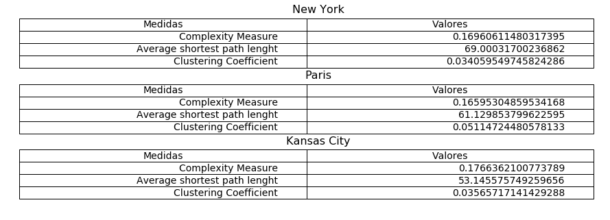

```python
# plotando tabelas
fig,(ax1,ax2,ax3) = plt.subplots(3,1,figsize=(15,5))

for ax in [ax1,ax2,ax3]:
    ax.axis('tight')
    ax.axis('off')

labels = ['Medidas','Valores']

# New York
tb_ny = ax1.table(cellText=table_ny,colLabels=labels,cellLoc='right',loc='best')
tb_ny.set_fontsize(14)
tb_ny.scale(1, 1.5)
ax1.set_title("New York", fontsize=16)

# Paris
tb_ps = ax2.table(cellText=table_ps,colLabels=labels,cellLoc='right',loc='best')
tb_ps.set_fontsize(14)
tb_ps.scale(1, 1.5)
ax2.set_title("Paris", fontsize=16)

# Kansas City
tb_ks = ax3.table(cellText=table_ks,colLabels=labels,cellLoc='right',loc='best')
tb_ks.set_fontsize(14)
tb_ks.scale(1, 1.5)
ax3.set_title("Kansas City", fontsize=16)

plt.show()
```

#### Conclusão

> **NOTA:** Como não foi possível processar grades amostras de dados das cidades, os dados podem estar muito longe da realidade.